# **INSPER – INSTITUTO DE ENSINO E PESQUISA** *Curso de Economia* **Problemas em Economia** **Tema:** A Relação entre a Independência do Banco Central e a Potência da Política Monetária

Professores:** Juliana Inhasz Sérgio Ricardo Martins Paulo Jose Mencacci Costa (Prof. Auxiliar)

Integrantes:** Caio Santa Rosa Christovam – caiosrc@al.insper.edu.br Érika Kaori Fuzisaka – erikakf1@al.insper.edu.br Hicham Munir Tayfour – hichamt@al.insper.edu.br Lucas Batista Ferreira – lucasbf1@al.insper.edu.br Maria Antonia Pereira Guimarães – mariaapg1@al.insper.edu.br Maria Eduarda Marques Pereira – mariaemp@al.insper.edu.br Maria Morais Garcia Leal – mariamgl@al.insper.edu.br

São Paulo – Fevereiro de 2025

# 1 Hipótese de Pesquisa

Este estudo busca avaliar empiricamente a seguinte hipótese:

> **Hipótese**: Quanto maior o grau de independência do Banco Central, maior será a potência da política monetária no controle inflacionário.

Mais especificamente, assume-se que bancos centrais com maior autonomia institucional possuem maior credibilidade e capacidade de ancorar expectativas, o que se reflete em uma resposta mais efetiva da inflação à política monetária.

Para testar essa hipótese, será conduzida uma análise empírica baseada em dados internacionais, com foco na relação entre: - O **grau de independência do Banco Central** (medido por um índice padronizado ou por classificação categórica), e - A **potência da política monetária**, avaliada por meio da resposta da inflação a variações na taxa de juros real.

Modelos econométricos e análises descritivas complementares serão utilizados para investigar essa relação ao longo do tempo e entre diferentes grupos de países (por regime monetário e instituições).

# 2 ⚙️ Configuração do Ambiente

```r
knitr::opts_chunk$set(fig.width=15, fig.height=10)
```

# 3 📦 Carregando Pacotes

```r
# Manipulação e Visualização de Dados
library(tidyverse)
library(dplyr)
library(ggplot2)
library(ggthemes)
library(ggtext)
library(patchwork)
library(gridExtra)
library(CGPfunctions)
library(scales)
library(viridis)
library(ggstream)
library(gganimate)

# Análise de Séries Temporais e Dados Econômicos
library(tidyquant)
library(WDI)
library(imf.data)
library(seasonal)
library(mFilter)
library(zoo)
library(sidrar)

# Modelagem e Econometria
library(plm)
library(broom)

# Geodados e Mapas
library(rnaturalearth)
library(sf)
library(countrycode)

# Leitura e Organização de Dados
library(readxl)
library(labelled)

# Tabelas Profissionais
library(gt)
library(gtExtras)
```

# 4 📃 Importando e Ajustando as Bases de Dados

Nesta seção, realizamos a importação e integração das principais bases de dados macroeconômicos utilizadas no estudo. As informações são obtidas a partir de fontes confiáveis, como o Banco Mundial (WDI), o FMI (IFS), e arquivos auxiliares em Excel contendo o índice de independência dos Bancos Centrais e expectativas de inflação. O objetivo é construir uma base padronizada, consistente e apropriada para a análise empírica.

## 4.1 📥 Download de Indicadores do Banco Mundial

```r
# Consulta aos indicadores disponíveis no WDI
indicadores <- WDIsearch()

# Lista de agrupamentos macroeconômicos para exclusão
agrupamentos <- c(
  "Africa Eastern and Southern", "Africa Western and Central", "Arab World",
  "Early-demographic dividend", "East Asia & Pacific",
  "East Asia & Pacific (excluding high income)",
  "East Asia & Pacific (IDA & IBRD countries)", "Euro area",
  "Europe & Central Asia", "Europe & Central Asia (excluding high income)",
  "Europe & Central Asia (IDA & IBRD countries)", "European Union",
  "Fragile and conflict affected situations", "Heavily indebted poor countries (HIPC)",
  "High income", "IBRD only", "IDA & IBRD total", "IDA blend", "IDA only",
  "IDA total", "Late-demographic dividend", "Latin America & Caribbean",
  "Latin America & Caribbean (excluding high income)",
  "Latin America & the Caribbean (IDA & IBRD countries)",
  "Least developed countries: UN classification", "Low & middle income",
  "Low income", "Lower middle income", "Middle East & North Africa",
  "Middle East & North Africa (excluding high income)",
  "Middle East & North Africa (IDA & IBRD countries)", "Middle income",
  "Not classified", "OECD members", "Other small states",
  "Pacific island small states", "Post-demographic dividend",
  "Pre-demographic dividend", "Small states", "South Asia",
  "South Asia (IDA & IBRD)", "Sub-Saharan Africa",
  "Sub-Saharan Africa (excluding high income)",
  "Sub-Saharan Africa (IDA & IBRD countries)", "Upper middle income", "World"
)
```

## 4.2 📊 Importação e Tratamento das Variáveis Econômicas

```r
# PIB real (constante, US$ 2015)
gdp <- WDI("all", "NY.GDP.MKTP.KD", 1960) %>%
  filter(!country %in% agrupamentos) %>%
  select(country, iso2c, iso3c, year, NY.GDP.MKTP.KD) %>%
  rename(pib = NY.GDP.MKTP.KD) %>%
  arrange(country, year)

# Inflação (deflator do PIB)
cpi <- WDI("all", "NY.GDP.DEFL.KD.ZG", 1960) %>%
  filter(!country %in% agrupamentos) %>%
  select(country, iso2c, iso3c, year, NY.GDP.DEFL.KD.ZG) %>%
  rename(inflation = NY.GDP.DEFL.KD.ZG) %>%
  arrange(country, year)

# Dívida governamental (% do PIB)
debt <- WDI("all", "GC.DOD.TOTL.GD.ZS", 1960) %>%
  filter(!country %in% agrupamentos) %>%
  select(country, iso2c, iso3c, year, GC.DOD.TOTL.GD.ZS) %>%
  rename(divida = GC.DOD.TOTL.GD.ZS) %>%
  arrange(country, year)
```

## 4.3 📁 Bases Complementares: Independência do BC e Expectativas

```r
# Índice de independência do Banco Central (base CBIE)
cbi <- readxl::read_xlsx("CBIDta.xlsx", sheet = "Data") %>%
  select(country, iso_a3, year, cbie_index) %>%
  mutate(year = as.numeric(year)) %>%
  arrange(country, year) %>%
  rename(iso3c = iso_a3) %>%
  select(country, iso3c, year, cbie_index)

# Expectativas de inflação (FMI)
inf_for <- readxl::read_xlsx("InflationForecast(FMI).xlsx") %>%
  select(Country, Code, Year, `Inflation forecast`) %>%
  rename(
    inflation_forecast = `Inflation forecast`,
    country = Country,
    code = Code,
    year = Year
  ) %>%
  mutate(iso3c = countrycode::countrycode(country, "country.name", "iso3c"))
```

## 4.4 💰 Taxa de Juros de Política Monetária (FMI - IFS)

```r
# Importação da base IFS do FMI
ifs <- imf.data::load_datasets("IFS")

# Seleção da série de taxa de juros
data_wide <- ifs$get_series(
  freq         = "A",
  ref_area     = NULL,
  indicator    = "FPOLM_PA",
  start_period = "1960",
  end_period   = "2025"
)

# Transformação da base
rate <- data_wide %>%
  pivot_longer(cols = -TIME_PERIOD, names_to = "col_indicator", values_to = "taxa_juros") %>%
  mutate(
    iso2c = sub("^A\\.(.*?)\\.FPOLM_PA$", "\\1", col_indicator),
    year  = as.numeric(TIME_PERIOD),
    iso2c = case_when(iso2c %in% c("7A", "U2") ~ "EA", TRUE ~ iso2c),
    iso3c = countrycode::countrycode(iso2c, "iso2c", "iso3c"),
    country = countrycode::countrycode(iso2c, "iso2c", "country.name")
  ) %>%
  filter(!is.na(country)) %>%
  select(country, iso2c, iso3c, year, taxa_juros)
```

## 4.5 Base de dados “Própria”

```r
target <- data.frame(
  Pais = c("New Zealand", "Canada", "Chile", "Israel", "United Kingdom", "Sweden",
           "Finland", "Australia", "Spain", "Czech Republic", "Poland", "Brazil",
           "Colombia", "South Africa", "Thailand", "South Korea", "Mexico",
           "Iceland", "Norway", "Hungary", "Peru", "Philippines", "Guatemala",
           "Indonesia", "Romania", "Turkey", "Serbia", "Ghana", "Uruguay",
           "Albania", "Georgia", "Armenia", "Japan", "India", "Russia",
           "Moldova", "Paraguay", "Uganda", "Dominican Republic"),
  AnoAdocao = c(1989, 1991, 1991, 1991, 1992, 1993,
                1993, 1993, 1994, 1997, 1998, 1999,
                1999, 2000, 2000, 2001, 2001,
                2001, 2001, 2001, 2002, 2002, 2005,
                2005, 2005, 2006, 2007, 2007,
                2009, 2009, 2009, 2013, 2015, 2014,
                2010, 2011, 2011, 2012, 2015),
  SegueAtualmente = c("sim", "sim", "sim", "sim", "sim", "sim",
                      "não", "sim", "não", "sim", "sim", "sim",
                      "sim", "sim", "sim", "sim", "sim",
                      "sim", "sim", "sim", "sim", "sim", "sim",
                      "sim", "não", "sim", "sim", "sim",
                      "sim", "sim", "sim", "sim", "sim", "sim",
                      "sim", "sim", "sim", "sim", "sim")
)

acemoglu_classification <- data.frame(
  Pais = c("Argentina", "Australia", "Austria", "Brazil", "Chile",
           "Denmark", "Finland", "France", "Greece", "Guatemala",
           "India", "Indonesia", "Korea", "Malaysia", "Mexico",
           "Mongolia", "Netherlands", "Norway", "Paraguay","Philippines",
           "Portugal", "Spain", "Sweden", "Switzerland", "Turkey", "United Kingdom",
           "Uruguay"),
  Classe = c("Medium", "High", "High", "Medium", "Medium",
             "High", "High", "Medium", "Medium", "Low",
             "Medium", "Low", "Medium", "Medium", "Medium",
             "Medium", "High", "High", "Low", "Medium",
             "Medium", "Medium", "High", "High", "Medium",
             "High", "Medium")
)
```

# 5 🧩 Integração das Bases e Construção da Base Final

```r
# Juntando todas as variáveis
data <- cbi %>%
  inner_join(cpi  %>% select(-country), by = c("iso3c", "year")) %>%
  inner_join(debt %>% select(-country), by = c("iso3c", "year")) %>%
  inner_join(gdp  %>% select(-country), by = c("iso3c", "year")) %>%
  inner_join(rate %>% select(-country), by = c("iso3c", "year")) %>%
  inner_join(inf_for %>% select(-country), by = c("iso3c", "year")) %>%
  filter(year >= 2000) %>%
  select(-c(iso2c.y, iso2c.x.x, iso2c.y.y)) %>%
  rename(iso2c = iso2c.x) %>%
  group_by(country) %>%
  arrange(year) %>%
  mutate(
    taxa_juros = as.numeric(taxa_juros),
    pib_pot   = mFilter::hpfilter(pib, freq = 6.25)$trend,
    hiato_pct = ((pib - pib_pot) / pib_pot) * 100,
    real_rate = ((1 + taxa_juros) / (1 + inflation)) - 1
  ) %>%
  ungroup() %>%
  arrange(country, year) %>%
  select(
    country, iso3c, iso2c, year,
    pib, inflation, inflation_forecast, taxa_juros,
    cbie_index, divida, pib_pot, hiato_pct, real_rate
  ) %>%
  labelled::set_variable_labels(
    pib                = "GDP (constant 2015 US$)",
    inflation          = "Inflação (%)",
    inflation_forecast = "Expectativa de Inflação (%)",
    taxa_juros         = "Taxa de juros nominal (%)(BC)",
    cbie_index         = "Índice de independência do Banco Central",
    divida             = "Dívida governamental (% do PIB)",
    pib_pot            = "PIB potencial (filtro HP)",
    hiato_pct          = "Hiato do produto (%)",
    real_rate          = "Taxa de juros real (%)"
  ) %>%
  mutate(across(where(~ inherits(.x, "matrix")), as.numeric))
```

# 6 🔎 Visualização Inicial da Base Final

```r
# Visualização da base final
data %>%
  glimpse()
```

```
## Rows: 1,814
## Columns: 13
## $ country            <chr> "Afghanistan", "Afghanistan", "Afghanistan", "Afgha…
## $ iso3c              <chr> "AFG", "AFG", "AFG", "AFG", "AFG", "AFG", "AFG", "A…
## $ iso2c              <chr> "AF", "AF", "AF", "AF", "AF", "AF", "AF", "AF", "AF…
## $ year               <dbl> 2003, 2004, 2005, 2006, 2007, 2008, 2009, 2010, 201…
## $ pib                <dbl> 7867263256, 7978515642, 8874480196, 9349921886, 106…
## $ inflation          <dbl> 11.6552382, 11.2714321, 10.9127736, 7.1997513, 22.5…
## $ inflation_forecast <dbl> 6.53, 13.27, 10.56, 4.29, 16.09, 18.81, -9.84, 10.2…
## $ taxa_juros         <dbl> NA, NA, NA, NA, NA, NA, NA, NA, NA, NA, NA, NA, 1.8…
## $ cbie_index         <dbl> 0.870, 0.870, 0.870, 0.870, 0.870, 0.870, 0.870, 0.…
## $ divida             <dbl> NA, NA, NA, NA, NA, NA, NA, NA, NA, NA, NA, NA, NA,…
## $ pib_pot            <dbl> 7439590152, 8104209549, 8837256643, 9687048105, 107…
## $ hiato_pct          <dbl> 5.74861109, -1.55097060, 0.42121163, -3.48017492, -…
## $ real_rate          <dbl> NA, NA, NA, NA, NA, NA, NA, NA, NA, NA, NA, NA, -0.…
```

# 7 📈 Análise Descritiva

## 7.1 📊 Gráfico de Cobertura de Dados

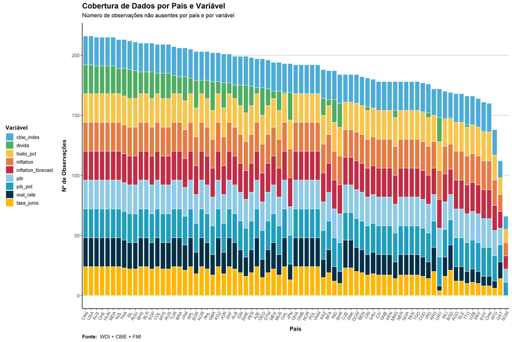

```r
data %>%
  mutate(across(
    c(
      pib,
      inflation,
      inflation_forecast,
      taxa_juros,
      cbie_index,
      divida,
      pib_pot,
      hiato_pct,
      real_rate
    ),
    ~ as.numeric(.x)
  )) %>%
  select(
    iso3c,
    pib,
    inflation,
    inflation_forecast,
    taxa_juros,
    cbie_index,
    divida,
    pib_pot,
    hiato_pct,
    real_rate
  ) %>%
  pivot_longer(cols = -iso3c,
               names_to = "variavel",
               values_to = "valor") %>%
  filter(!is.na(valor)) %>%
  count(iso3c, variavel, name = "n_obs") %>%
  ggplot(aes(
    x = fct_reorder(iso3c, -n_obs, .fun = sum),
    y = n_obs,
    fill = variavel
  )) +
  geom_bar(stat = "identity",
           color = "white",
           width = 0.85) +
  scale_fill_manual(
    values = c(
      "#4DACD6",
      "#4FAE62",
      "#F6C54D",
      "#E37D46",
      "#C02D45",
      "#8ecae6",
      "#219ebc",
      "#023047",
      "#ffb703"
    ),
    name = "Variável"
  ) +
  labs(
    title = "Cobertura de Dados por País e Variável",
    subtitle = "Número de observações não ausentes por país e por variável",
    x = "País",
    y = "Nº de Observações",
    caption = expression(bold("Fonte: ") ~ "WDI + CBIE + FMI")
  ) +
  theme_classic(base_size = 12) +
  theme(
    axis.text.x = element_text(
      angle = 60,
      hjust = 1,
      size = 9
    ),
    axis.title.x = element_text(face = "bold", margin = margin(t = 10)),
    axis.title.y = element_text(face = "bold", margin = margin(r = 10)),
    axis.text.y = element_text(size = 10),
    plot.title = element_text(face = "bold", size = 16, hjust = 0),
    plot.subtitle = element_text(
      size = 12,
      hjust = 0,
      margin = margin(b = 10)
    ),
    plot.caption = element_text(
      hjust = 0,
      size = 10,
      color = "black"
    ),
    legend.position = "left",
    legend.title = element_text(face = "bold"),
    legend.text = element_text(size = 10),
    panel.grid.major.y = element_line(color = "grey80"),
    panel.grid.major.x = element_blank()
  )
```

## 7.2 📊 Gráfico da Inflação Mundo

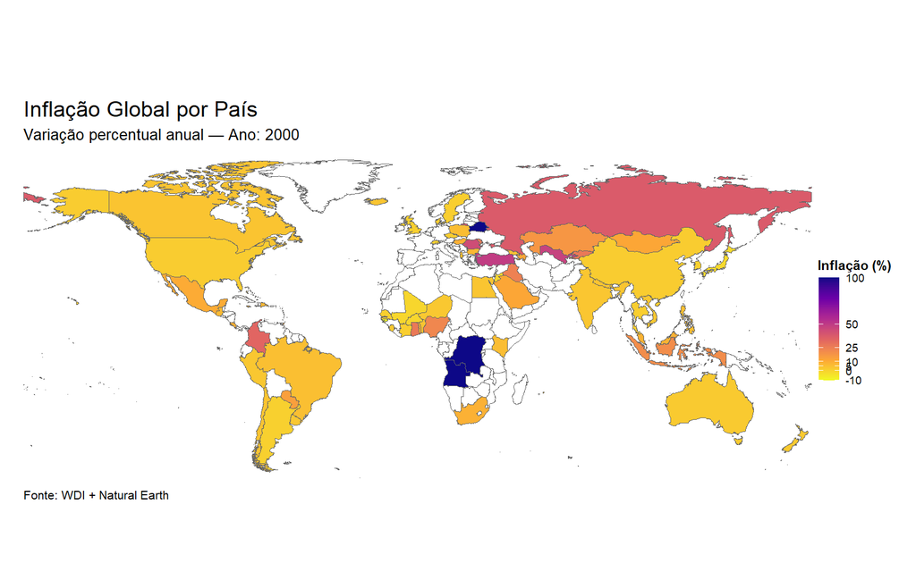

```r
# world <- ne_countries(scale = "medium", returnclass = "sf") %>%
#   filter(name != "Antarctica") %>%
#   select(iso_a3, geometry)
#
# grade_mapa <- expand_grid(iso_a3 = world$iso_a3, year = 2000:2023) %>%
#   left_join(world, by = "iso_a3") %>%
#   st_as_sf() %>%
#   left_join(data %>% filter(year >= 2000, year <= 2023),
#             by = c("iso_a3" = "iso3c", "year" = "year"))
#
# paleta_inflacao <- scale_fill_viridis_c(
#   option = "plasma",
#   direction = -1,
#   name = "Inflação (%)",
#   limits = c(-10, 100),
#   breaks = c(-10, 0, 5, 10, 25, 50, 100),
#   oob = squish,
#   na.value = "white"
# )
#
# p <- ggplot(grade_mapa) +
#   geom_sf(aes(fill = inflation),
#           color = "grey40",
#           size = 0.2) +
#   paleta_inflacao +
#   coord_sf(expand = FALSE) +
#   labs(title = "Inflação Global por País",
#        subtitle = "Variação percentual anual — Ano: {current_frame}",
#        caption = "Fonte: WDI + Natural Earth") +
#   theme_void(base_size = 11) +
#   theme(
#     plot.title    = element_text(face = "bold", size = 18, hjust = 0),
#     plot.subtitle = element_text(
#       size = 13,
#       hjust = 0,
#       margin = margin(b = 10)
#     ),
#     plot.caption  = element_text(
#       size = 10,
#       hjust = 0,
#       color = "black",
#       margin = margin(t = 10)
#     ),
#     legend.position = "right",
#     legend.title = element_text(face = "bold", size = 11),
#     legend.text  = element_text(size = 9),
#     plot.title.position = "plot",
#     plot.caption.position = "plot",
#     plot.margin = margin(
#       t = 60,
#       r = 20,
#       b = 40,
#       l = 20
#     )
#   ) +
#   transition_manual(year)
#
# anim_save(
#   "mapa_inflacao.gif",
#   animation = animate(
#     p,
#     fps = 2,
#     width = 1600,
#     height = 1000,
#     res = 150,
#     renderer = gifski_renderer()
#   )
# )
#
# p
```

## 7.3 📊 Gráfico da Evolução do CBI

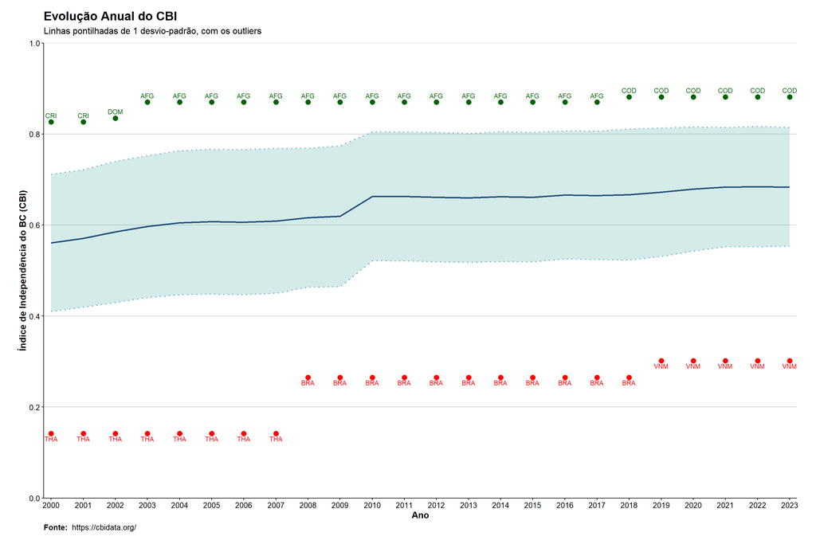

```r
ggplot() +
  geom_ribbon(
    data = data %>%
      group_by(year) %>%
      summarise(
        mean_cbie = mean(cbie_index, na.rm = TRUE),
        sd_cbie   = sd(cbie_index, na.rm = TRUE)
      ),
    aes(
      x = year,
      ymin = mean_cbie - sd_cbie,
      ymax = mean_cbie + sd_cbie
    ),
    fill = "#2A9D8F",
    alpha = 0.2
  ) +
  geom_line(
    data = data %>%
      group_by(year) %>%
      summarise(mean_cbie = mean(cbie_index, na.rm = TRUE)),
    aes(x = year, y = mean_cbie),
    color = "#1F4E79",
    size = 1
  ) +
  geom_line(
    data = data %>%
      group_by(year) %>%
      summarise(
        mean_cbie = mean(cbie_index, na.rm = TRUE),
        sd_cbie   = sd(cbie_index, na.rm = TRUE)
      ),
    aes(x = year, y = mean_cbie + sd_cbie),
    color = "#81B1D6",
    linetype = "dotted",
    size = 0.8
  ) +
  geom_line(
    data = data %>%
      group_by(year) %>%
      summarise(
        mean_cbie = mean(cbie_index, na.rm = TRUE),
        sd_cbie   = sd(cbie_index, na.rm = TRUE)
      ),
    aes(x = year, y = mean_cbie - sd_cbie),
    color = "#81B1D6",
    linetype = "dotted",
    size = 0.8
  ) +
  geom_point(
    data = data %>%
      group_by(year) %>%
      mutate(
        mean_cbie   = mean(cbie_index, na.rm = TRUE),
        sd_cbie     = sd(cbie_index, na.rm = TRUE),
        distance_up = cbie_index - (mean_cbie + sd_cbie)
      ) %>%
      filter(cbie_index > mean_cbie + sd_cbie) %>%
      slice_max(distance_up, with_ties = FALSE) %>%
      ungroup(),
    aes(x = year, y = cbie_index),
    color = "darkgreen",
    size = 3
  ) +
  geom_text(
    data = data %>%
      group_by(year) %>%
      mutate(
        mean_cbie   = mean(cbie_index, na.rm = TRUE),
        sd_cbie     = sd(cbie_index, na.rm = TRUE),
        distance_up = cbie_index - (mean_cbie + sd_cbie)
      ) %>%
      filter(cbie_index > mean_cbie + sd_cbie) %>%
      slice_max(distance_up, with_ties = FALSE) %>%
      ungroup(),
    aes(x = year, y = cbie_index, label = iso3c),
    color = "darkgreen",
    vjust = -0.8,
    size = 3
  ) +
  geom_point(
    data = data %>%
      group_by(year) %>%
      mutate(
        mean_cbie     = mean(cbie_index, na.rm = TRUE),
        sd_cbie       = sd(cbie_index, na.rm = TRUE),
        distance_down = (mean_cbie - sd_cbie) - cbie_index
      ) %>%
      filter(cbie_index < mean_cbie - sd_cbie) %>%
      slice_max(distance_down, with_ties = FALSE) %>%
      ungroup(),
    aes(x = year, y = cbie_index),
    color = "red",
    size = 3
  ) +
  geom_text(
    data = data %>%
      group_by(year) %>%
      mutate(
        mean_cbie     = mean(cbie_index, na.rm = TRUE),
        sd_cbie       = sd(cbie_index, na.rm = TRUE),
        distance_down = (mean_cbie - sd_cbie) - cbie_index
      ) %>%
      filter(cbie_index < mean_cbie - sd_cbie) %>%
      slice_max(distance_down, with_ties = FALSE) %>%
      ungroup(),
    aes(x = year, y = cbie_index, label = iso3c),
    color = "red",
    vjust = 1.5,
    size = 3
  ) +
  scale_x_continuous(breaks = sort(unique(data$year)), expand = expansion(mult = c(0.01, 0.01))) +
  scale_y_continuous(
    limits = c(0, 1),
    breaks = seq(0, 1, 0.2),
    expand = expansion(mult = c(0, 0))
  ) +
  labs(
    title    = "Evolução Anual do CBI",
    subtitle = "Linhas pontilhadas de 1 desvio-padrão, com os outliers",
    x        = "Ano",
    y        = "Índice de Independência do BC (CBI)",
    caption  = expression(bold("Fonte: ") ~ "https://cbidata.org/")
  ) +
  theme(
    plot.background    = element_rect(fill = "white", color = NA),
    panel.background   = element_rect(fill = "white", color = NA),
    panel.grid.major.y = element_line(color = "grey80"),
    panel.grid.major.x = element_blank(),
    panel.grid.minor   = element_blank(),
    axis.line.x.bottom = element_line(color = "black"),
    axis.line.y.left   = element_line(color = "black"),
    axis.ticks         = element_line(color = "black"),
    plot.title         = element_text(face = "bold", size = 16, hjust = 0),
    plot.subtitle      = element_text(
      size = 12,
      hjust = 0,
      margin = margin(b = 10)
    ),
    axis.title         = element_text(face = "bold", size = 12),
    axis.text          = element_text(size = 10, color = "black"),
    plot.caption       = element_text(
      hjust = 0,
      size = 10,
      color = "black"
    ),
    plot.margin        = margin(15, 25, 15, 25)
  )
```

## 7.4 📊 Gráfico da Inflação anual

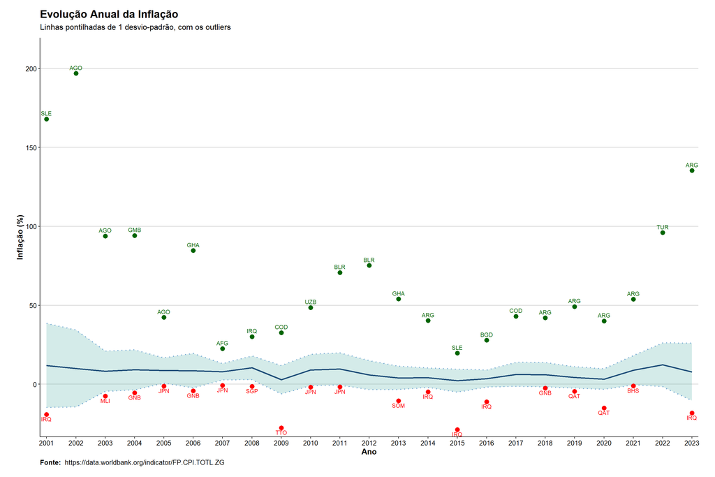

```r
ggplot() +
  geom_ribbon(
    data = data %>%
      filter(year > 2000) %>%
      group_by(year) %>%
      summarise(
        mean_inflation = mean(inflation, na.rm = TRUE),
        sd_inflation   = sd(inflation, na.rm = TRUE)
      ),
    aes(
      x = year,
      ymin = mean_inflation - sd_inflation,
      ymax = mean_inflation + sd_inflation
    ),
    fill = "#2A9D8F",
    alpha = 0.2
  ) +
  geom_line(
    data = data %>%
      filter(year > 2000) %>%
      group_by(year) %>%
      summarise(mean_inflation = mean(inflation, na.rm = TRUE)),
    aes(x = year, y = mean_inflation),
    color = "#1F4E79",
    size = 1
  ) +
  geom_line(
    data = data %>%
      filter(year > 2000) %>%
      group_by(year) %>%
      summarise(
        mean_inflation = mean(inflation, na.rm = TRUE),
        sd_inflation   = sd(inflation, na.rm = TRUE)
      ),
    aes(x = year, y = mean_inflation + sd_inflation),
    color = "#81B1D6",
    linetype = "dotted",
    size = 0.8
  ) +
  geom_line(
    data = data %>%
      filter(year > 2000) %>%
      group_by(year) %>%
      summarise(
        mean_inflation = mean(inflation, na.rm = TRUE),
        sd_inflation   = sd(inflation, na.rm = TRUE)
      ),
    aes(x = year, y = mean_inflation - sd_inflation),
    color = "#81B1D6",
    linetype = "dotted",
    size = 0.8
  ) +
  geom_point(
    data = data %>%
      filter(year > 2000) %>%
      group_by(year) %>%
      mutate(
        mean_inflation = mean(inflation, na.rm = TRUE),
        sd_inflation   = sd(inflation, na.rm = TRUE),
        distance_up = inflation - (mean_inflation + sd_inflation)
      ) %>%
      filter(inflation > mean_inflation + sd_inflation) %>%
      slice_max(distance_up, with_ties = FALSE) %>%
      ungroup(),
    aes(x = year, y = inflation),
    color = "darkgreen",
    size = 3
  ) +
  geom_text(
    data = data %>%
      filter(year > 2000) %>%
      group_by(year) %>%
      mutate(
        mean_inflation = mean(inflation, na.rm = TRUE),
        sd_inflation   = sd(inflation, na.rm = TRUE),
        distance_up = inflation - (mean_inflation + sd_inflation)
      ) %>%
      filter(inflation > mean_inflation + sd_inflation) %>%
      slice_max(distance_up, with_ties = FALSE) %>%
      ungroup(),
    aes(x = year, y = inflation, label = iso3c),
    color = "darkgreen",
    vjust = -0.8,
    size = 3
  ) +
  geom_point(
    data = data %>%
      filter(year > 2000) %>%
      group_by(year) %>%
      mutate(
        mean_inflation = mean(inflation, na.rm = TRUE),
        sd_inflation   = sd(inflation, na.rm = TRUE),
        distance_down = (mean_inflation - sd_inflation) - inflation
      ) %>%
      filter(inflation < mean_inflation - sd_inflation) %>%
      slice_max(distance_down, with_ties = FALSE) %>%
      ungroup(),
    aes(x = year, y = inflation),
    color = "red",
    size = 3
  ) +
  geom_text(
    data = data %>%
      filter(year > 2000) %>%
      group_by(year) %>%
      mutate(
        mean_inflation = mean(inflation, na.rm = TRUE),
        sd_inflation   = sd(inflation, na.rm = TRUE),
        distance_down = (mean_inflation - sd_inflation) - inflation
      ) %>%
      filter(inflation < mean_inflation - sd_inflation) %>%
      slice_max(distance_down, with_ties = FALSE) %>%
      ungroup(),
    aes(x = year, y = inflation, label = iso3c),
    color = "red",
    vjust = 1.5,
    size = 3
  ) +
  scale_x_continuous(
    breaks = sort(unique(data %>% filter(year > 2000) %>% pull(year))),
    expand = expansion(mult = c(0.01, 0.01))
  ) +
  scale_y_continuous(
    expand = expansion(mult = c(0.02, 0.1))
  ) +
  labs(
    title    = "Evolução Anual da Inflação",
    subtitle = "Linhas pontilhadas de 1 desvio-padrão, com os outliers",
    x        = "Ano",
    y        = "Inflação (%)",
    caption  = expression(bold("Fonte: ") ~ "https://data.worldbank.org/indicator/FP.CPI.TOTL.ZG")
  ) +
  theme(
    plot.background    = element_rect(fill = "white", color = NA),
    panel.background   = element_rect(fill = "white", color = NA),
    panel.grid.major.y = element_line(color = "grey80"),
    panel.grid.major.x = element_blank(),
    panel.grid.minor   = element_blank(),
    axis.line.x.bottom = element_line(color = "black"),
    axis.line.y.left   = element_line(color = "black"),
    axis.ticks         = element_line(color = "black"),
    plot.title         = element_text(face = "bold", size = 16, hjust = 0),
    plot.subtitle      = element_text(size = 12, hjust = 0, margin = margin(b = 10)),
    axis.title         = element_text(face = "bold", size = 12),
    axis.text          = element_text(size = 10, color = "black"),
    plot.caption       = element_text(hjust = 0, size = 10, color = "black"),
    plot.margin        = margin(15, 25, 15, 25)
  )
```

## 7.5 📊 Gráfico da Inflação anual (2000-Hoje; Países com Metas de inflação)

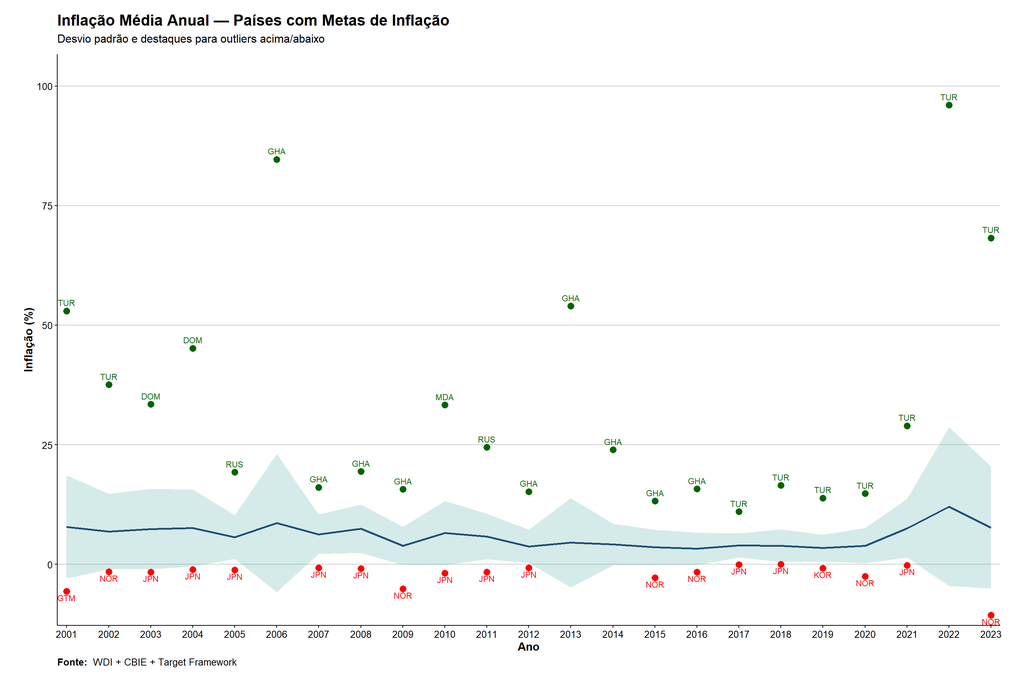

```r
ggplot() +
  geom_ribbon(
    data = data %>%
      filter(
        year > 2000,
        country %in% (target %>% filter(SegueAtualmente == "sim") %>% pull(Pais))
      ) %>%
      group_by(year) %>%
      summarise(
        mean_inflation = mean(inflation, na.rm = TRUE),
        sd_inflation   = sd(inflation, na.rm = TRUE),
        .groups = "drop"
      ),
    aes(
      x = year,
      ymin = mean_inflation - sd_inflation,
      ymax = mean_inflation + sd_inflation
    ),
    fill = "#2A9D8F", alpha = 0.2
  ) +
  geom_line(
    data = data %>%
      filter(
        year > 2000,
        country %in% (target %>% filter(SegueAtualmente == "sim") %>% pull(Pais))
      ) %>%
      group_by(year) %>%
      summarise(mean_inflation = mean(inflation, na.rm = TRUE), .groups = "drop"),
    aes(x = year, y = mean_inflation),
    color = "#1F4E79", size = 1
  ) +
  geom_point(
    data = data %>%
      filter(
        year > 2000,
        country %in% (target %>% filter(SegueAtualmente == "sim") %>% pull(Pais))
      ) %>%
      group_by(year) %>%
      mutate(
        mean_inflation = mean(inflation, na.rm = TRUE),
        sd_inflation   = sd(inflation, na.rm = TRUE),
        distance_up    = inflation - (mean_inflation + sd_inflation)
      ) %>%
      filter(inflation > mean_inflation + sd_inflation) %>%
      slice_max(distance_up, with_ties = FALSE) %>%
      ungroup(),
    aes(x = year, y = inflation),
    color = "darkgreen", size = 3
  ) +
  geom_text(
    data = data %>%
      filter(
        year > 2000,
        country %in% (target %>% filter(SegueAtualmente == "sim") %>% pull(Pais))
      ) %>%
      group_by(year) %>%
      mutate(
        mean_inflation = mean(inflation, na.rm = TRUE),
        sd_inflation   = sd(inflation, na.rm = TRUE),
        distance_up    = inflation - (mean_inflation + sd_inflation)
      ) %>%
      filter(inflation > mean_inflation + sd_inflation) %>%
      slice_max(distance_up, with_ties = FALSE) %>%
      ungroup(),
    aes(x = year, y = inflation, label = iso3c),
    color = "darkgreen", vjust = -0.8, size = 3
  ) +
  geom_point(
    data = data %>%
      filter(
        year > 2000,
        country %in% (target %>% filter(SegueAtualmente == "sim") %>% pull(Pais))
      ) %>%
      group_by(year) %>%
      mutate(
        mean_inflation = mean(inflation, na.rm = TRUE),
        sd_inflation   = sd(inflation, na.rm = TRUE),
        distance_down  = (mean_inflation - sd_inflation) - inflation
      ) %>%
      filter(inflation < mean_inflation - sd_inflation) %>%
      slice_max(distance_down, with_ties = FALSE) %>%
      ungroup(),
    aes(x = year, y = inflation),
    color = "red", size = 3
  ) +
  geom_text(
    data = data %>%
      filter(
        year > 2000,
        country %in% (target %>% filter(SegueAtualmente == "sim") %>% pull(Pais))
      ) %>%
      group_by(year) %>%
      mutate(
        mean_inflation = mean(inflation, na.rm = TRUE),
        sd_inflation   = sd(inflation, na.rm = TRUE),
        distance_down  = (mean_inflation - sd_inflation) - inflation
      ) %>%
      filter(inflation < mean_inflation - sd_inflation) %>%
      slice_max(distance_down, with_ties = FALSE) %>%
      ungroup(),
    aes(x = year, y = inflation, label = iso3c),
    color = "red", vjust = 1.5, size = 3
  ) +
  scale_x_continuous(
    breaks = sort(unique(data %>%
                           filter(year > 2000, country %in% (target %>% filter(SegueAtualmente == "sim") %>% pull(Pais))) %>%
                           pull(year))),
    expand = expansion(mult = c(0.01, 0.01))
  ) +
  scale_y_continuous(
    expand = expansion(mult = c(0.02, 0.1))
  ) +
  labs(
    title    = "Inflação Média Anual — Países com Metas de Inflação",
    subtitle = "Desvio padrão e destaques para outliers acima/abaixo",
    x        = "Ano",
    y        = "Inflação (%)",
    caption  = expression(bold("Fonte: ") ~ "WDI + CBIE + Target Framework")
  ) +
  theme(
    plot.background    = element_rect(fill = "white", color = NA),
    panel.background   = element_rect(fill = "white", color = NA),
    panel.grid.major.y = element_line(color = "grey80"),
    panel.grid.major.x = element_blank(),
    panel.grid.minor   = element_blank(),
    axis.line.x.bottom = element_line(color = "black"),
    axis.line.y.left   = element_line(color = "black"),
    axis.ticks         = element_line(color = "black"),
    plot.title         = element_text(face = "bold", size = 16, hjust = 0),
    plot.subtitle      = element_text(size = 12, hjust = 0, margin = margin(b = 10)),
    axis.title         = element_text(face = "bold", size = 12),
    axis.text          = element_text(size = 10, color = "black"),
    plot.caption       = element_text(hjust = 0, size = 10, color = "black"),
    plot.margin        = margin(15, 25, 15, 25)
  )
```

## 7.6 📊 Gráfico do PIB de Acordo com as Classificações do Acemoglu

### 7.6.1 📊 Gráfico do PIB Países High

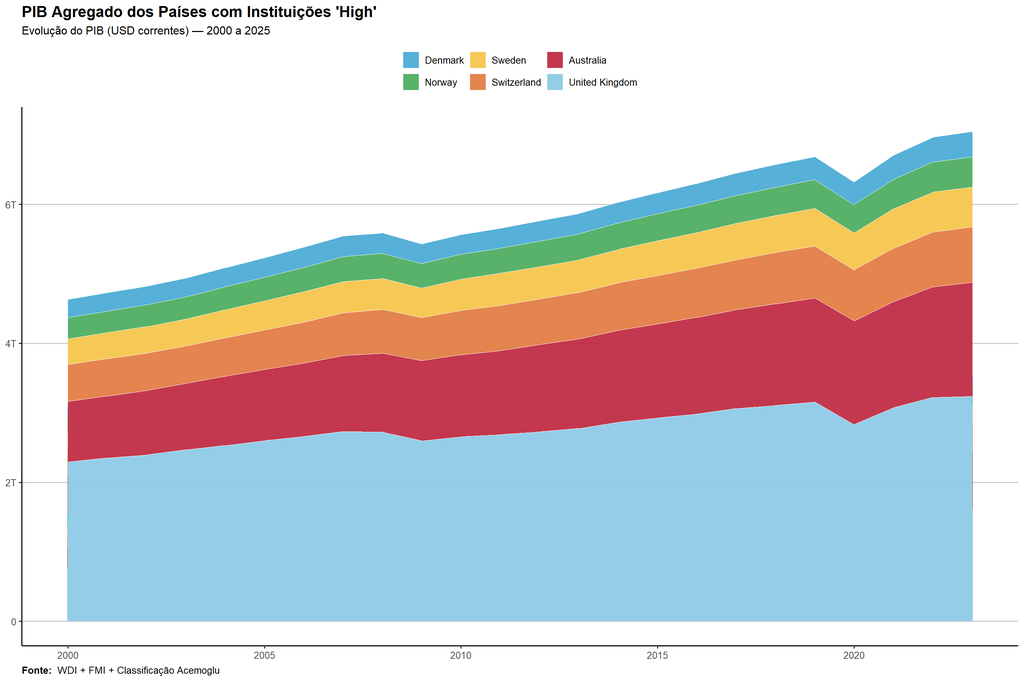

```r
data %>%
  left_join(acemoglu_classification, by = c("country" = "Pais")) %>%
  filter(Classe == "High", !is.na(pib)) %>%
  group_by(year, country) %>%
  summarise(pib_total = sum(pib, na.rm = TRUE), .groups = "drop") %>%
  mutate(country = fct_reorder(country, pib_total, .fun = sum)) %>%
  ggplot(aes(x = year, y = pib_total, fill = country)) +
  geom_area(color = "white",
            size = 0.1,
            alpha = 0.95) +
  scale_fill_manual(
    values = c(
      "#4DACD6",
      "#4FAE62",
      "#F6C54D",
      "#E37D46",
      "#C02D45",
      "#8ecae6",
      "#219ebc",
      "#023047",
      "#ffb703"
    )
  ) +
  scale_y_continuous(labels = label_number(scale_cut = cut_short_scale())) +
  labs(
    title = "PIB Agregado dos Países com Instituições 'High'",
    subtitle = "Evolução do PIB (USD correntes) — 2000 a 2025",
    caption = expression(bold("Fonte: ") ~ "WDI + FMI + Classificação Acemoglu"),
    x = NULL,
    y = NULL
  ) +
  theme_classic(base_size = 12) +
  theme(
    axis.text.x = element_text(size = 10),
    axis.text.y = element_text(size = 10),
    axis.title.x = element_text(face = "bold", margin = margin(t = 10)),
    axis.title.y = element_text(face = "bold", margin = margin(r = 10)),
    plot.title = element_text(face = "bold", size = 16, hjust = 0),
    plot.subtitle = element_text(
      size = 12,
      hjust = 0,
      margin = margin(b = 10)
    ),
    plot.caption = element_text(
      hjust = 0,
      size = 10,
      color = "black"
    ),
    legend.position = "top",
    legend.title = element_blank(),
    legend.text = element_text(size = 10),
    panel.grid.major.y = element_line(color = "grey80"),
    panel.grid.major.x = element_blank()
  )
```

### 7.6.2 📊 Gráfico do PIB Países Medium

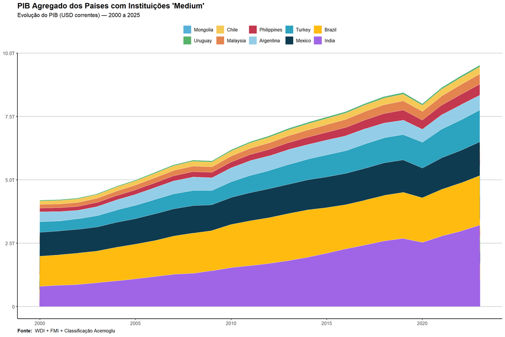

```r
data %>%
  left_join(acemoglu_classification, by = c("country" = "Pais")) %>%
  filter(Classe == "Medium", !is.na(pib)) %>%
  group_by(year, country) %>%
  summarise(pib_total = sum(pib, na.rm = TRUE), .groups = "drop") %>%
  mutate(country = fct_reorder(country, pib_total, .fun = sum)) %>%
  ggplot(aes(x = year, y = pib_total, fill = country)) +
  geom_area(color = "white",
            size = 0.1,
            alpha = 0.95) +
  scale_fill_manual(
    values = c(
      "#4DACD6",
      "#4FAE62",
      "#F6C54D",
      "#E37D46",
      "#C02D45",
      "#8ecae6",
      "#219ebc",
      "#023047",
      "#ffb703",
      "#9b5de5"
    )
  ) +
  scale_y_continuous(labels = label_number(scale_cut = cut_short_scale())) +
  labs(
    title = "PIB Agregado dos Países com Instituições 'Medium'",
    subtitle = "Evolução do PIB (USD correntes) — 2000 a 2025",
    caption = expression(bold("Fonte: ") ~ "WDI + FMI + Classificação Acemoglu"),
    x = NULL,
    y = NULL
  ) +
  theme_classic(base_size = 12) +
  theme(
    axis.text.x = element_text(size = 10),
    axis.text.y = element_text(size = 10),
    axis.title.x = element_text(face = "bold", margin = margin(t = 10)),
    axis.title.y = element_text(face = "bold", margin = margin(r = 10)),
    plot.title = element_text(face = "bold", size = 16, hjust = 0),
    plot.subtitle = element_text(
      size = 12,
      hjust = 0,
      margin = margin(b = 10)
    ),
    plot.caption = element_text(
      hjust = 0,
      size = 10,
      color = "black"
    ),
    legend.position = "top",
    legend.title = element_blank(),
    legend.text = element_text(size = 10),
    panel.grid.major.y = element_line(color = "grey80"),
    panel.grid.major.x = element_blank()
  )
```

### 7.6.3 📊 Gráfico do PIB Países Low

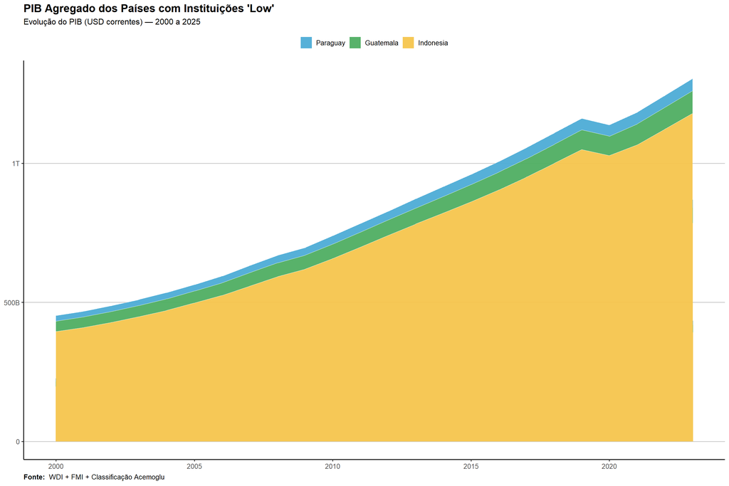

```r
data %>%
  left_join(acemoglu_classification, by = c("country" = "Pais")) %>%
  filter(Classe == "Low", !is.na(pib)) %>%
  group_by(year, country) %>%
  summarise(pib_total = sum(pib, na.rm = TRUE), .groups = "drop") %>%
  mutate(country = fct_reorder(country, pib_total, .fun = sum)) %>%
  ggplot(aes(x = year, y = pib_total, fill = country)) +
  geom_area(color = "white",
            size = 0.1,
            alpha = 0.95) +
  scale_fill_manual(
    values = c(
      "#4DACD6",
      "#4FAE62",
      "#F6C54D",
      "#E37D46",
      "#C02D45",
      "#8ecae6",
      "#219ebc",
      "#023047",
      "#ffb703",
      "#9b5de5"
    )
  ) +
  scale_y_continuous(labels = label_number(scale_cut = cut_short_scale())) +
  labs(
    title = "PIB Agregado dos Países com Instituições 'Low'",
    subtitle = "Evolução do PIB (USD correntes) — 2000 a 2025",
    caption = expression(bold("Fonte: ") ~ "WDI + FMI + Classificação Acemoglu"),
    x = NULL,
    y = NULL
  ) +
  theme_classic(base_size = 12) +
  theme(
    axis.text.x = element_text(size = 10),
    axis.text.y = element_text(size = 10),
    axis.title.x = element_text(face = "bold", margin = margin(t = 10)),
    axis.title.y = element_text(face = "bold", margin = margin(r = 10)),
    plot.title = element_text(face = "bold", size = 16, hjust = 0),
    plot.subtitle = element_text(
      size = 12,
      hjust = 0,
      margin = margin(b = 10)
    ),
    plot.caption = element_text(
      hjust = 0,
      size = 10,
      color = "black"
    ),
    legend.position = "top",
    legend.title = element_blank(),
    legend.text = element_text(size = 10),
    panel.grid.major.y = element_line(color = "grey80"),
    panel.grid.major.x = element_blank()
  )
```

## 7.7 📊 Gráfico da Resposta da Inflação à Taxa Real de Juros

### 7.7.1 📊 Gráfico da Resposta da Inflação à Taxa Real de Juros High

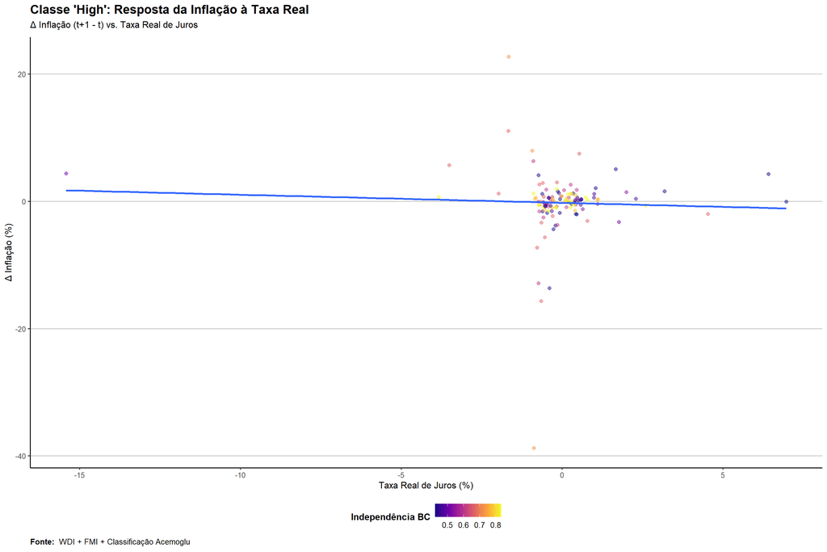

```r
data %>%
  left_join(acemoglu_classification, by = c("country" = "Pais")) %>%
  group_by(country) %>%
  mutate(
    inflacao_a_frente = dplyr::lead(inflation, 1),
    delta_inflacao = inflacao_a_frente - inflation
  ) %>%
  ungroup() %>%
  filter(
    Classe == "High",
    !is.na(real_rate),
    !is.na(delta_inflacao),
    !is.na(cbie_index)
  ) %>%
  ggplot(aes(x = real_rate, y = delta_inflacao, color = cbie_index)) +
  geom_point(alpha = 0.5, size = 2) +
  geom_smooth(method = "lm", se = FALSE, linewidth = 1.2) +
  scale_color_viridis_c(option = "plasma", name = "Independência BC") +
  labs(
    title = "Classe 'High': Resposta da Inflação à Taxa Real",
    subtitle = "Δ Inflação (t+1 - t) vs. Taxa Real de Juros",
    x = "Taxa Real de Juros (%)",
    y = "Δ Inflação (%)",
    caption = expression(bold("Fonte: ") ~ "WDI + FMI + Classificação Acemoglu")
  ) +
  theme_classic(base_size = 12) +
  theme(
    plot.title = element_text(face = "bold", size = 16, hjust = 0),
    plot.subtitle = element_text(size = 12, hjust = 0, margin = margin(b = 10)),
    plot.caption = element_text(size = 10, hjust = 0),
    legend.position = "bottom",
    legend.title = element_text(face = "bold"),
    legend.text = element_text(size = 10),
    panel.grid.major.y = element_line(color = "grey80"),
    panel.grid.major.x = element_blank()
  )
```

### 7.7.2 📊 Gráfico da Resposta da Inflação à Taxa Real de Juros Medium

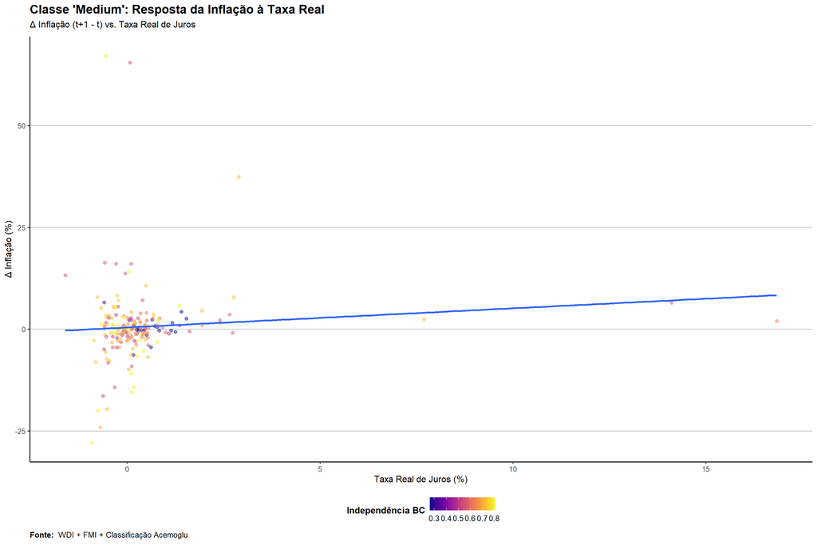

```r
data %>%
  left_join(acemoglu_classification, by = c("country" = "Pais")) %>%
  group_by(country) %>%
  mutate(
    inflacao_a_frente = dplyr::lead(inflation, 1),
    delta_inflacao = inflacao_a_frente - inflation
  ) %>%
  ungroup() %>%
  filter(
    Classe == "Medium",
    !is.na(real_rate),
    !is.na(delta_inflacao),
    !is.na(cbie_index)
  ) %>%
  ggplot(aes(x = real_rate, y = delta_inflacao, color = cbie_index)) +
  geom_point(alpha = 0.5, size = 2) +
  geom_smooth(method = "lm", se = FALSE, linewidth = 1.2) +
  scale_color_viridis_c(option = "plasma", name = "Independência BC") +
  labs(
    title = "Classe 'Medium': Resposta da Inflação à Taxa Real",
    subtitle = "Δ Inflação (t+1 - t) vs. Taxa Real de Juros",
    x = "Taxa Real de Juros (%)",
    y = "Δ Inflação (%)",
    caption = expression(bold("Fonte: ") ~ "WDI + FMI + Classificação Acemoglu")
  ) +
  theme_classic(base_size = 12) +
  theme(
    plot.title = element_text(face = "bold", size = 16, hjust = 0),
    plot.subtitle = element_text(size = 12, hjust = 0, margin = margin(b = 10)),
    plot.caption = element_text(size = 10, hjust = 0),
    legend.position = "bottom",
    legend.title = element_text(face = "bold"),
    legend.text = element_text(size = 10),
    panel.grid.major.y = element_line(color = "grey80"),
    panel.grid.major.x = element_blank()
  )
```

### 7.7.3 📊 Gráfico da Resposta da Inflação à Taxa Real de Juros Low

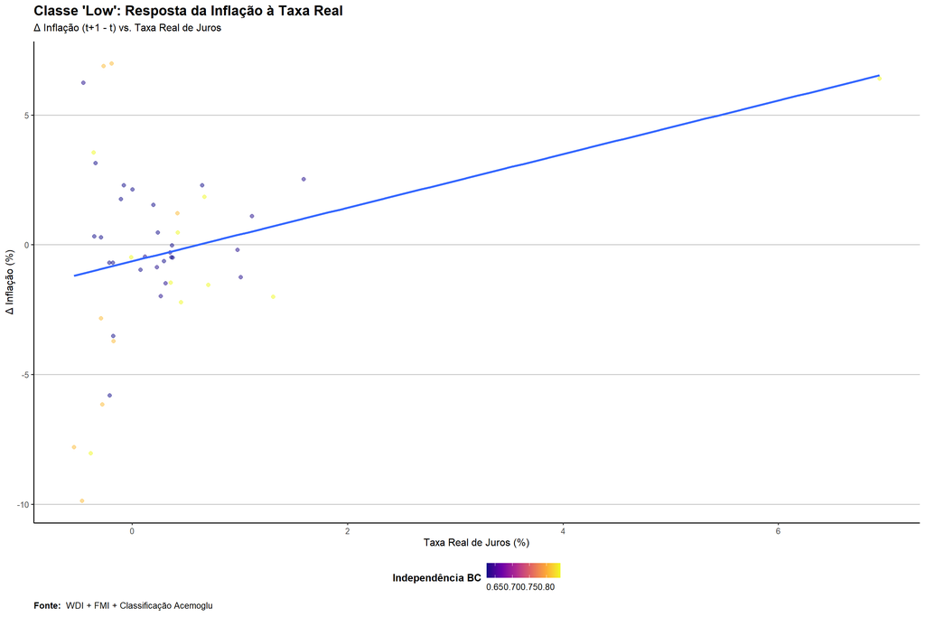

```r
data %>%
  left_join(acemoglu_classification, by = c("country" = "Pais")) %>%
  group_by(country) %>%
  mutate(
    inflacao_a_frente = dplyr::lead(inflation, 1),
    delta_inflacao = inflacao_a_frente - inflation
  ) %>%
  ungroup() %>%
  filter(
    Classe == "Low",
    !is.na(real_rate),
    !is.na(delta_inflacao),
    !is.na(cbie_index)
  ) %>%
  ggplot(aes(x = real_rate, y = delta_inflacao, color = cbie_index)) +
  geom_point(alpha = 0.5, size = 2) +
  geom_smooth(method = "lm", se = FALSE, linewidth = 1.2) +
  scale_color_viridis_c(option = "plasma", name = "Independência BC") +
  labs(
    title = "Classe 'Low': Resposta da Inflação à Taxa Real",
    subtitle = "Δ Inflação (t+1 - t) vs. Taxa Real de Juros",
    x = "Taxa Real de Juros (%)",
    y = "Δ Inflação (%)",
    caption = expression(bold("Fonte: ") ~ "WDI + FMI + Classificação Acemoglu")
  ) +
  theme_classic(base_size = 12) +
  theme(
    plot.title = element_text(face = "bold", size = 16, hjust = 0),
    plot.subtitle = element_text(size = 12, hjust = 0, margin = margin(b = 10)),
    plot.caption = element_text(size = 10, hjust = 0),
    legend.position = "bottom",
    legend.title = element_text(face = "bold"),
    legend.text = element_text(size = 10),
    panel.grid.major.y = element_line(color = "grey80"),
    panel.grid.major.x = element_blank()
  )
```

## 7.8 📊 Gráfico da Inflação contra a Inflação Esperada (com ou sem regime de meta)

### 7.8.1 📊 Gráfico da Inflação contra a Inflação Esperada no Regime de Metas

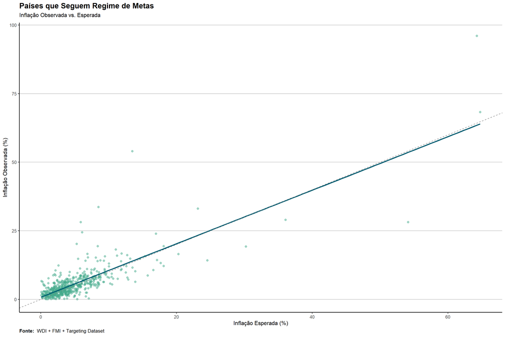

```r
data %>%
  left_join(target, by = c("country" = "Pais")) %>%
  filter(
    !is.na(AnoAdocao),
    SegueAtualmente == "sim",
    year >= AnoAdocao,
    !is.na(inflation),
    !is.na(inflation_forecast),
    inflation > 0,
    inflation_forecast > 0
  ) %>%
  ggplot(aes(x = inflation_forecast, y = inflation)) +
  geom_point(alpha = 0.5, size = 2, color = "#43aa8b") +
  geom_smooth(method = "lm", se = FALSE, color = "#005f73", linewidth = 1.2) +
  geom_abline(slope = 1, intercept = 0, linetype = "dashed", color = "grey50") +
  labs(
    title = "Países que Seguem Regime de Metas",
    subtitle = "Inflação Observada vs. Esperada",
    x = "Inflação Esperada (%)",
    y = "Inflação Observada (%)",
    caption = expression(bold("Fonte: ") ~ "WDI + FMI + Targeting Dataset")
  ) +
  theme_classic(base_size = 12) +
  theme(
    plot.title = element_text(face = "bold", size = 16, hjust = 0),
    plot.subtitle = element_text(size = 12, hjust = 0, margin = margin(b = 10)),
    plot.caption = element_text(size = 10, hjust = 0),
    panel.grid.major.y = element_line(color = "grey80"),
    panel.grid.major.x = element_blank()
  )
```

### 7.8.2 📊 Gráfico da Inflação contra a Inflação Esperada que saíram do Regime de Metas

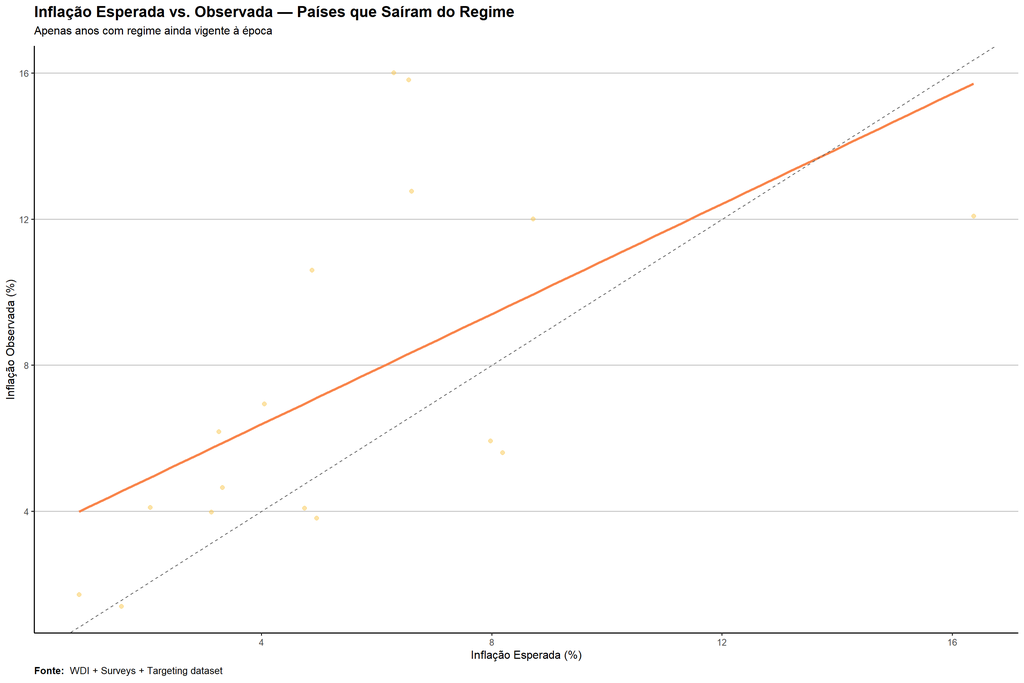

```r
data %>%
  left_join(target, by = c("country" = "Pais")) %>%
  filter(
    !is.na(AnoAdocao),
    SegueAtualmente != "sim",
    year >= AnoAdocao,
    !is.na(inflation),
    !is.na(inflation_forecast),
    inflation > 0,
    inflation_forecast > 0
  ) %>%
  ggplot(aes(x = inflation_forecast, y = inflation)) +
  geom_point(alpha = 0.5, size = 2, color = "#f9c74f") +
  geom_smooth(method = "lm", se = FALSE, linewidth = 1.2, color = "#f9844a") +
  geom_abline(intercept = 0, slope = 1, linetype = "dashed", color = "grey40") +
  labs(
    title = "Inflação Esperada vs. Observada — Países que Saíram do Regime",
    subtitle = "Apenas anos com regime ainda vigente à época",
    x = "Inflação Esperada (%)",
    y = "Inflação Observada (%)",
    caption = expression(bold("Fonte: ") ~ "WDI + Surveys + Targeting dataset")
  ) +
  theme_classic(base_size = 12) +
  theme(
    plot.title = element_text(face = "bold", size = 16, hjust = 0),
    plot.subtitle = element_text(size = 12, hjust = 0, margin = margin(b = 10)),
    plot.caption = element_text(size = 10, hjust = 0),
    panel.grid.major.y = element_line(color = "grey80"),
    panel.grid.major.x = element_blank()
  )
```

### 7.8.3 📊 Gráfico da Inflação contra a Inflação Esperada (sem regime de meta)

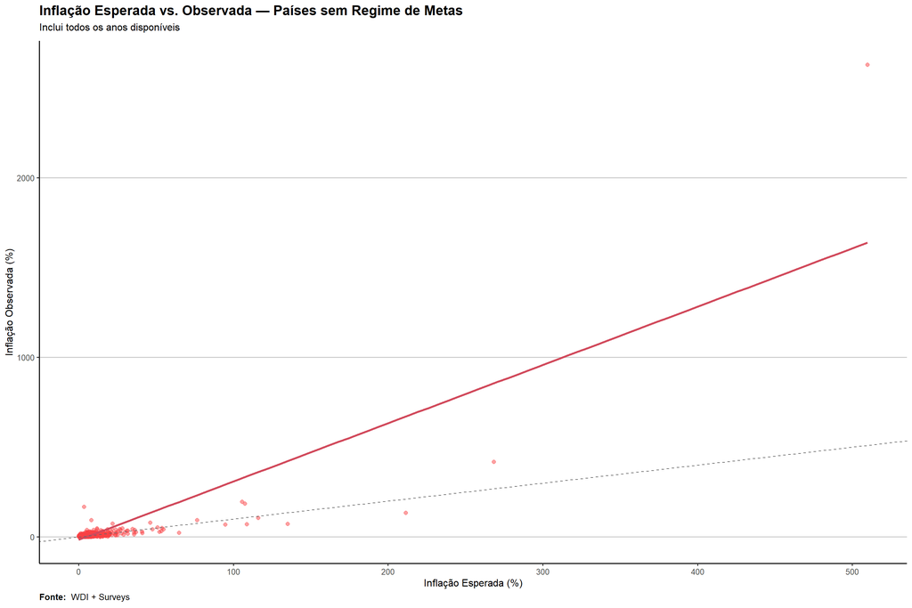

```r
data %>%
  left_join(target, by = c("country" = "Pais")) %>%
  filter(
    is.na(AnoAdocao),
    !is.na(inflation),
    !is.na(inflation_forecast),
    inflation > 0,
    inflation_forecast > 0
  ) %>%
  ggplot(aes(x = inflation_forecast, y = inflation)) +
  geom_point(alpha = 0.5, size = 2, color = "#f94144") +
  geom_smooth(method = "lm", se = FALSE, linewidth = 1.2, color = "#d1495b") +
  geom_abline(intercept = 0, slope = 1, linetype = "dashed", color = "grey40") +
  labs(
    title = "Inflação Esperada vs. Observada — Países sem Regime de Metas",
    subtitle = "Inclui todos os anos disponíveis",
    x = "Inflação Esperada (%)",
    y = "Inflação Observada (%)",
    caption = expression(bold("Fonte: ") ~ "WDI + Surveys")
  ) +
  theme_classic(base_size = 12) +
  theme(
    plot.title = element_text(face = "bold", size = 16, hjust = 0),
    plot.subtitle = element_text(size = 12, hjust = 0, margin = margin(b = 10)),
    plot.caption = element_text(size = 10, hjust = 0),
    panel.grid.major.y = element_line(color = "grey80"),
    panel.grid.major.x = element_blank()
  )
```

## 7.9 📊 Gráfico da média do CBIE dados países que seguem ou não as metas de inflação

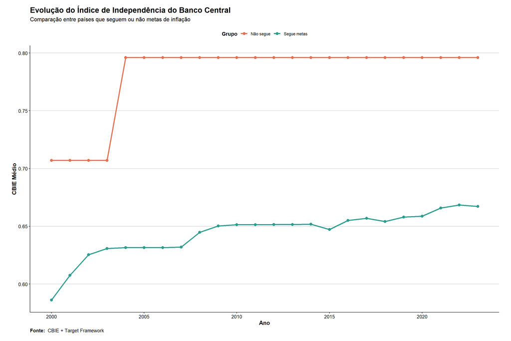

```r
data %>%
  filter(
    year >= 2000,
    country %in% (target %>% pull(Pais))
  ) %>%
  mutate(grupo_target = if_else(
    country %in% (target %>% filter(SegueAtualmente == "sim") %>% pull(Pais)),
    "Segue metas", "Não segue"
  )) %>%
  group_by(year, grupo_target) %>%
  summarise(cbie_medio = mean(cbie_index, na.rm = TRUE), .groups = "drop") %>%
  ggplot(aes(x = year, y = cbie_medio, color = grupo_target)) +
  geom_line(size = 1.2) +
  geom_point(size = 2.5) +
  scale_color_manual(values = c("Segue metas" = "#2A9D8F", "Não segue" = "#E76F51")) +
  labs(
    title = "Evolução do Índice de Independência do Banco Central",
    subtitle = "Comparação entre países que seguem ou não metas de inflação",
    x = "Ano", y = "CBIE Médio", color = "Grupo",
    caption = expression(bold("Fonte: ") ~ "CBIE + Target Framework")
  ) +
  theme(
    plot.background    = element_rect(fill = "white", color = NA),
    panel.background   = element_rect(fill = "white", color = NA),
    panel.grid.major.y = element_line(color = "grey80"),
    panel.grid.major.x = element_blank(),
    panel.grid.minor   = element_blank(),
    axis.line.x.bottom = element_line(color = "black"),
    axis.line.y.left   = element_line(color = "black"),
    axis.ticks         = element_line(color = "black"),
    plot.title         = element_text(face = "bold", size = 16, hjust = 0),
    plot.subtitle      = element_text(size = 12, hjust = 0, margin = margin(b = 10)),
    axis.title         = element_text(face = "bold", size = 12),
    axis.text          = element_text(size = 10, color = "black"),
    legend.title       = element_text(face = "bold"),
    legend.position    = "top",
    plot.caption       = element_text(hjust = 0, size = 10, color = "black"),
    plot.margin        = margin(15, 25, 15, 25)
  )
```